# Boston Bluebikes Data Investigation

## by Ayman Metwally

## Investigation Overview

- In this investigation, I will go through the following questions:
1. When are most trips taken in terms of time of day, day of the week, or month of the year?
2. How long does the average trip take?
3. Does the above depend on if a user is a subscriber or customer?
4. What is the most active stations?

## Dataset Overview

- This document explores a dataset containing about 2.5 millions bike trips across **Boston** City through **2019** including start & end stations & times, users types, genders & birth years.
- You can find it [here](https://www.bluebikes.com/system-data).

## Most Trips During Time of Day, Day of The Week & Month of The Year

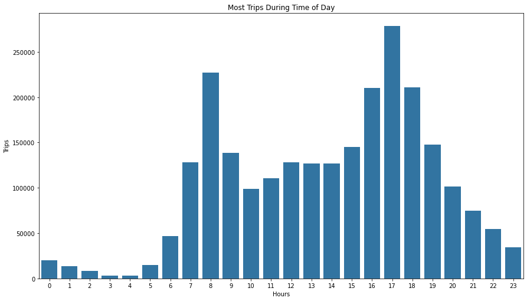

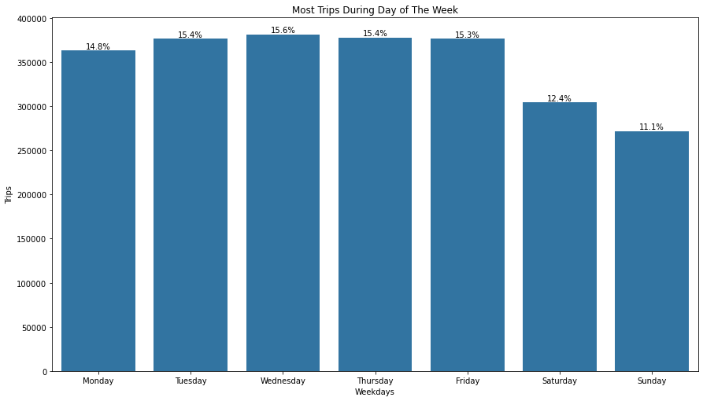

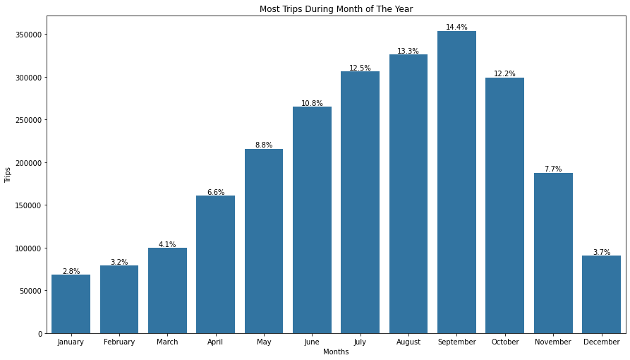

## Trips Duration Distribution

- Trips duration distribution is much skewed to the right (shorter trips) with a peak @ (6:9 mins) bin & a mean of 14.8 minutes.

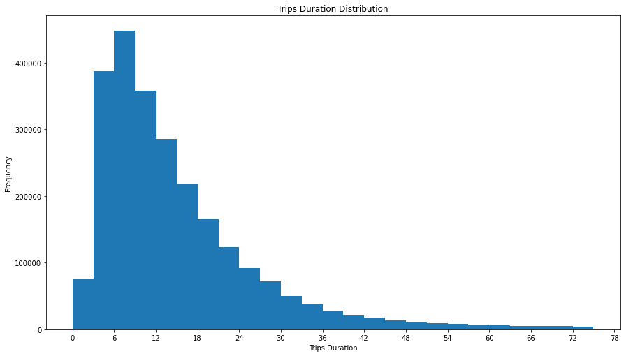

## Average Trip Duration of Different Users Type

- Subscribers have much shorter trips on average duration than customers through all months & all weekdays.
- Heatmaps show some differences on avergae trips duration distributions between both types.
- Subscribers are used to have longer trips from 2 am to 4 am & slightly shorter trips thoughout the day on work days whereas customers are used to have shorter trips from 4 am to 9 am & longer trips thoughout the day on work days.
- Both types have the same distributions on weekends except that customers have longer trips.

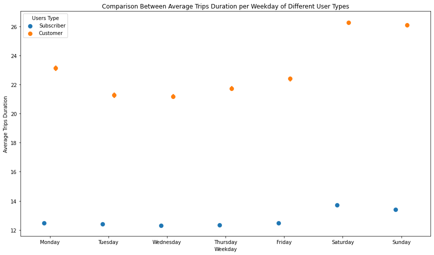

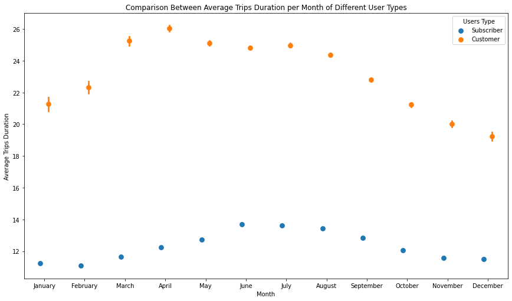

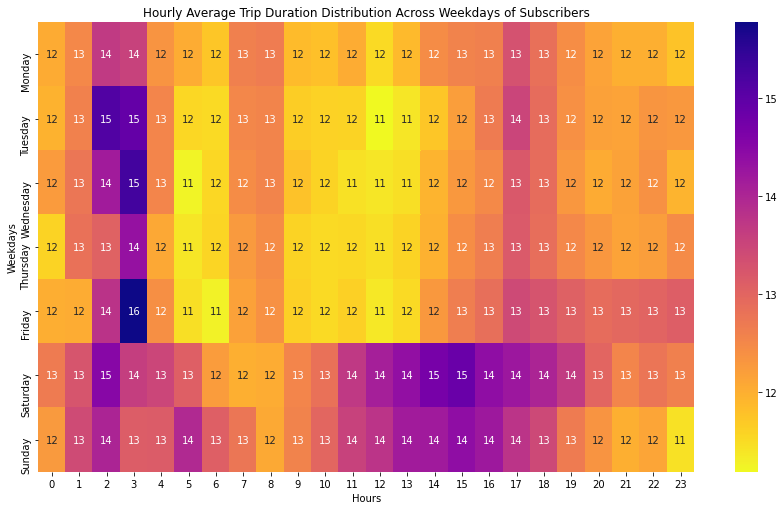

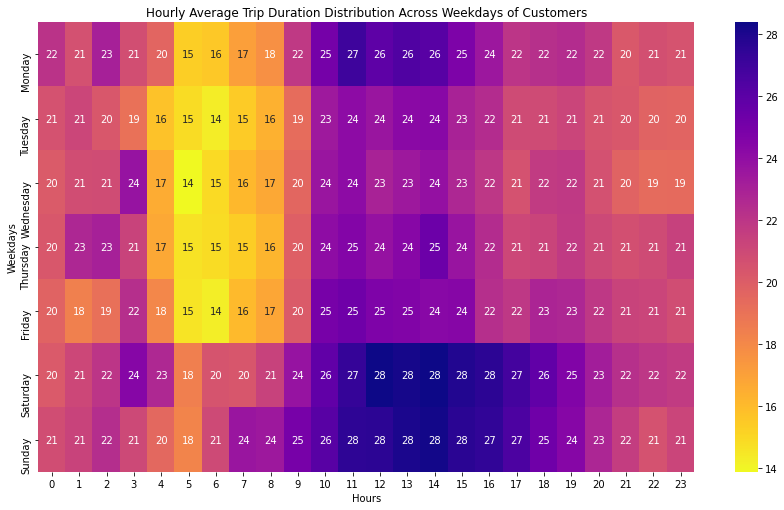

## The most active stations

- The top two start & end stations are:

| No. | Station | Start Times | End Times |
| --- | --- | --- | --- |
| 1 | MIT at Mass Ave / Amherst St | 60149 | 56255 |
| 2 | Central Square at Mass Ave / Essex St | 50345 | 50861 |

- The top two common trips (from start to end) are:
1. From **MIT Pacific St at Purrington St** to **MIT Stata Center at Vassar St / Main St** with 4942 occurrences
2. From **MIT Stata Center at Vassar St / Main St** to **MIT Pacific St at Purrington St** with 4884 occurrences

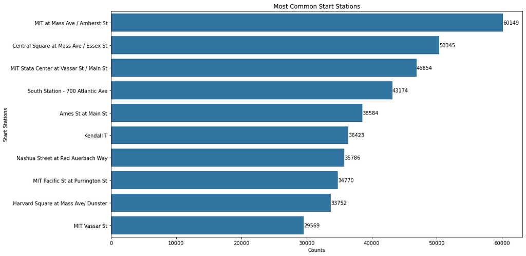

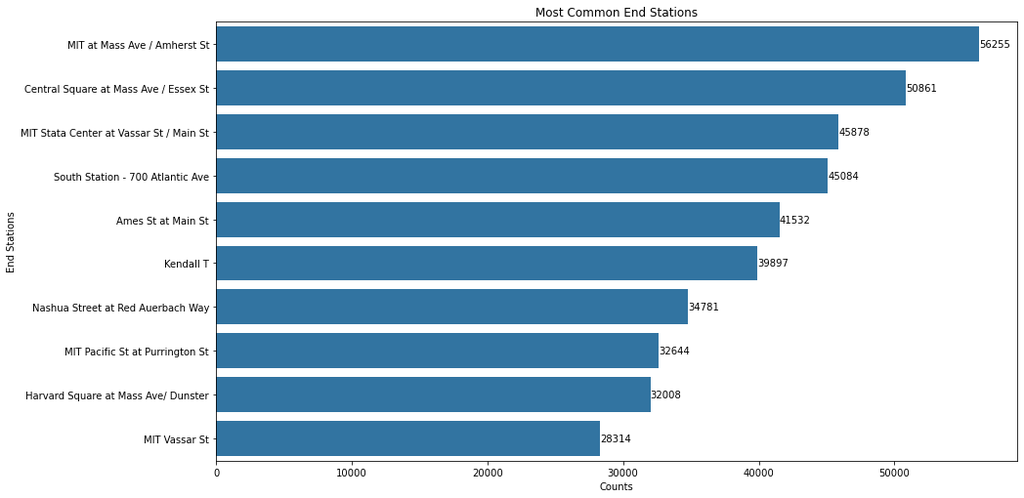

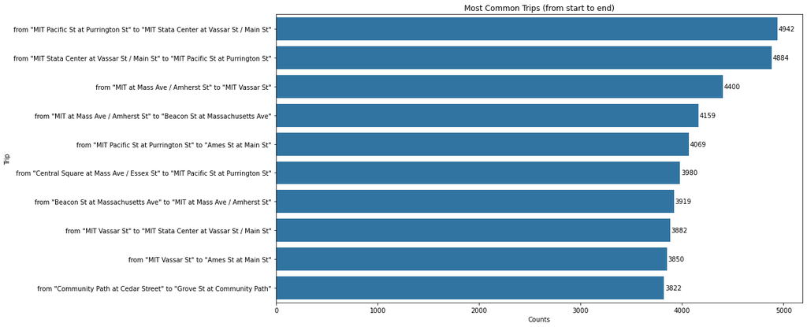

### Diving into the top two common trips

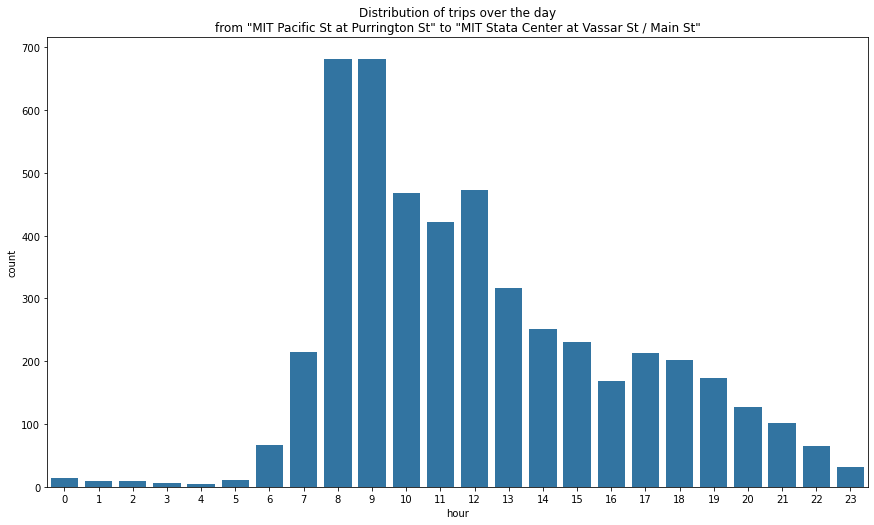

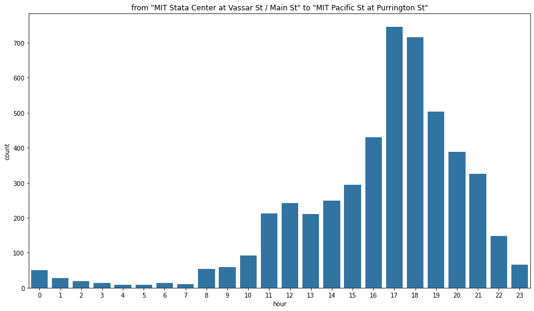

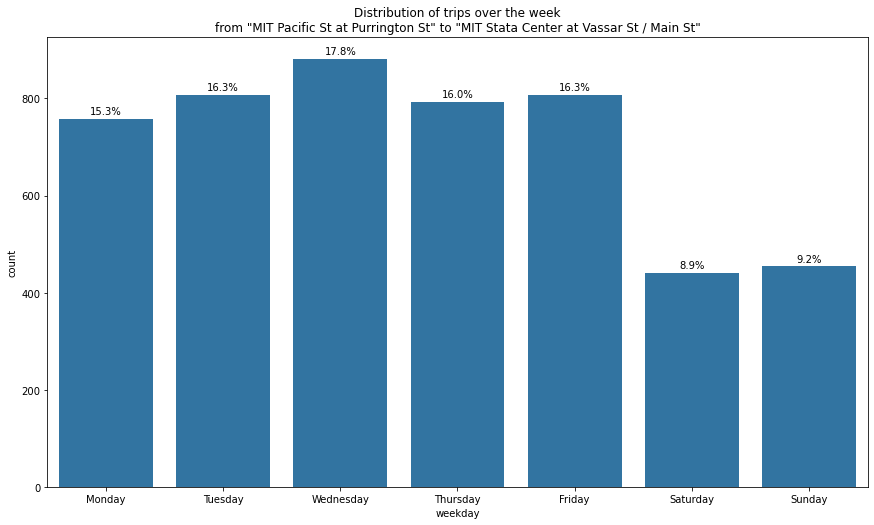

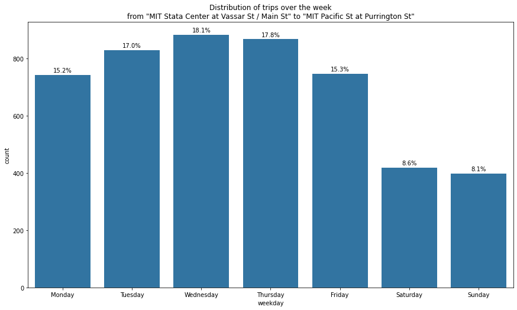